# Assignment One

Halan Badilla Osorio

```r
Sys.setenv("LANGUAGE"="EN")
```

# Problem One:

Explain whether each scenario is a classification or regression problem, and indicate whether we are most interested in inference or prediction. Finally, provide n (number of observations) and p (number of predictors).

1. We collect a set of data on the top 500 firms in the US. For each firm we record profit, number of employees, industry and the CEO salary. We are interested in understanding which factors affect CEO salary.

### Comment: Regression, Inference, n=500, p=3 (profit, employees, and industry)

2. We are considering launching a new product and wish to know whether it will be a success or a failure. We collect data on 20 similar products that were previously launched. For each product we have recorded whether it was a success or failure, price charged for the product, marketing budget, competition price,and ten other variables.

### Comment: Classification, Prediction, n=20, p=13 (price, marketing, competition price, + 10 other variables)

3. We are interested in predicting the % change in the USD/Euro exchange rate in relation to the weekly changes in the world stock markets. Hence we collect weekly data for all of 2012. For each week we record the % change in the USD/Euro, the % change in the US market, the % change in the British market, and the % change in the German market.

### Comment: Regression, Prediction, n=52, p=3 (% change in US, British and German market)

# Problem Two:

You will now think of some real-life applications for statistical learning.

1. Describe two real-life applications in which classification might be useful. Describe the response, as well as the predictors. Is the goal of each application inference or prediction? Explain your answer.

### Comment:

Understanding what affects students grades during senior year. Inference, you want to understand why the grades occured. Predicting how many blood bags of types of different bloods based what blood types are normally administered. Prediction, you’re predicting what will be necessary dependent on previous data.

2. Describe two real-life applications in which regression might be useful. Describe the response, as well as the predictors. Is the goal of each application inference or prediction? Explain your answer.

### Comment:

Future and current muscle gains. Predicting how much muscle you gain based on past muscle gain over time. Flight prices in the future, prediction, using previous data to guess what the price of a flight will be in the future.

# Problem Three:

This exercise relates to the College data set, which can be found in the file college.csv in canvas. It contains a number of variables for 777 different universities and colleges in the US. The variables are:

*note: < br > is just indicating a break and just makes the preview look better*

• Private : Public/private indicator  
• Apps : Number of applications received  
• Accept : Number of applicants accepted  
• Enroll : Number of new students enrolled  
• Top10perc : New students from top 10% of high school class  
• Top25perc : New students from top 25% of high school class  
• F.Undergrad : Number of full-time undergraduates  
• P.Undergrad : Number of part-time undergraduates  
• Outstate : Out-of-state tuition  
• Room.Board : Room and board costs  
• Books : Estimated book costs  
• Personal : Estimated personal spending  
• PhD : Percent of faculty with Ph.D.’s  
• Terminal : Percent of faculty with terminal degree  
• S.F.Ratio : Student/faculty ratio  
• perc.alumni : Percent of alumni who donate  
• Expend : Instructional expenditure per student  
• Grad.Rate : Graduation rate

Before reading the data into R, it can be viewed in Excel or a text editor.

1. Use the `read.csv()` function to read the data into R. Call the loaded data *college*. Make sure that you have the directory set to the correct location for the data.

```r
college <- read.csv("College.csv")
```

2. Look at the data using the `View()` function. You should notice that the first column is just the name of each university.We don’t really want R to treat this as data. However, it may be handy to have these names for later. Try the following commands:

```r
View(college)
```

```r
rownames(college) <- college[, 1]
View(college)
```

You should see that there is now a *row.names* column with the name of each university recorded. This means that R has given each row a name corresponding to the appropriate university. R will not try to perform calculations on the row names. However, we still need to eliminate the first column in the data where the names are stored. Try:

```r
college <- college[, -1]
View(college)
```

Now you should see that the first data column is *Private*. Note that another column labeled *row.names* now appears before the *Private column*. However, this is not a data column but rather the name that R is giving to each row.

3. 1. Use the `summary()` function to produce a numerical summary of the variables in the data set.

```r
summary(college)
```

```
   Private               Apps           Accept          Enroll       Top10perc       Top25perc      F.Undergrad     P.Undergrad         Outstate       Room.Board
 Length:777         Min.   :   81   Min.   :   72   Min.   :  35   Min.   : 1.00   Min.   :  9.0   Min.   :  139   Min.   :    1.0   Min.   : 2340   Min.   :1780
 Class :character   1st Qu.:  776   1st Qu.:  604   1st Qu.: 242   1st Qu.:15.00   1st Qu.: 41.0   1st Qu.:  992   1st Qu.:   95.0   1st Qu.: 7320   1st Qu.:3597
 Mode  :character   Median : 1558   Median : 1110   Median : 434   Median :23.00   Median : 54.0   Median : 1707   Median :  353.0   Median : 9990   Median :4200
                    Mean   : 3002   Mean   : 2019   Mean   : 780   Mean   :27.56   Mean   : 55.8   Mean   : 3700   Mean   :  855.3   Mean   :10441   Mean   :4358
                    3rd Qu.: 3624   3rd Qu.: 2424   3rd Qu.: 902   3rd Qu.:35.00   3rd Qu.: 69.0   3rd Qu.: 4005   3rd Qu.:  967.0   3rd Qu.:12925   3rd Qu.:5050
                    Max.   :48094   Max.   :26330   Max.   :6392   Max.   :96.00   Max.   :100.0   Max.   :31643   Max.   :21836.0   Max.   :21700   Max.   :8124
     Books           Personal         PhD            Terminal       S.F.Ratio      perc.alumni        Expend        Grad.Rate
 Min.   :  96.0   Min.   : 250   Min.   :  8.00   Min.   : 24.0   Min.   : 2.50   Min.   : 0.00   Min.   : 3186   Min.   : 10.00
 1st Qu.: 470.0   1st Qu.: 850   1st Qu.: 62.00   1st Qu.: 71.0   1st Qu.:11.50   1st Qu.:13.00   1st Qu.: 6751   1st Qu.: 53.00
 Median : 500.0   Median :1200   Median : 75.00   Median : 82.0   Median :13.60   Median :21.00   Median : 8377   Median : 65.00
 Mean   : 549.4   Mean   :1341   Mean   : 72.66   Mean   : 79.7   Mean   :14.09   Mean   :22.74   Mean   : 9660   Mean   : 65.46
 3rd Qu.: 600.0   3rd Qu.:1700   3rd Qu.: 85.00   3rd Qu.: 92.0   3rd Qu.:16.50   3rd Qu.:31.00   3rd Qu.:10830   3rd Qu.: 78.00
 Max.   :2340.0   Max.   :6800   Max.   :103.00   Max.   :100.0   Max.   :39.80   Max.   :64.00   Max.   :56233   Max.   :118.00
```

2. Use the `pairs()` function to produce a scatterplot matrix of the first ten columns or variables of the data. Recall that you can reference the first ten columns of a matrix A using A[,1:10].

```r
college[,2] = as.numeric(factor(college[,1]))
pairs(college[,1:10])
```

```
Error in pairs.default(college[, 1:10]) : non-numeric argument to 'pairs'
```

3. Use the `plot()` function to produce side-by-side boxplots of *Outstate* versus *Private*.

[figure not shown]

4. Create a new qualitative variable, called Elite, by binning the *Top10perc* variable. We are going to divide universities into two groups based on whether or not the proportion of students coming from the top 10% of their high school classes exceeds 50 %.

```r
Elite <- rep("No", nrow(college))
Elite[college$Top10perc > 50] <- "Yes"
Elite <- as.factor(Elite)
college <- data.frame(college , Elite)
```

22. Use the `summary()` function to see how many elite universities there are. Then use the `plot()` function to produce side-by-side boxplots of *Outstate* versus *Elite*.

```r
summary(Elite)
```

```
 No Yes
699  78
```

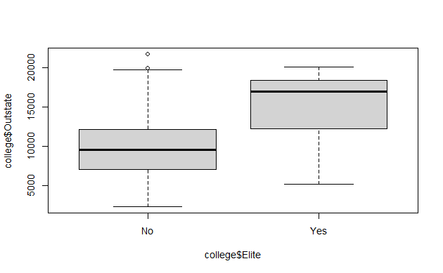

6. Use the `hist()` function to produce some histograms with differing numbers of bins for a few of the quantitative variables. You may find the command par(mfrow = c(2, 2)) useful: it will divide the print window into four regions so that four plots can be made simultaneously. Modifying the arguments to this function will divide the screen in other ways.

```r
Enroll <- college$Enroll
Grad_Rate <- college$Grad.Rate
Applications <- college$Apps
Accepted_Applications <- college$Accept

par(mfrow = c(2,2))
hist(Applications)
hist(Accepted_Applications)
```

[figure not shown]

```r
hist(Enroll)
hist(Grad_Rate)
```

[output not shown]

7. Continue exploring the data, and provide a brief summary of what you discover. (This can be as short as you like.)

# Problem Four:

This exercise involves the Auto data set in canvas. Make sure that the missing values have been removed from the data. This can be done using the `na.omit()` function which removes missing values from data.

```r
#na.omit(NameofData)
Auto <- read.csv("Auto.csv")
na.omit(Auto)
```

[output not shown]

[output cut: 387 more lines]

[output not shown]

1. Which of the predictors are quantitative, and which are qualitative?

```r
view(Auto)
```

```
Error in view(Auto) : could not find function "view"
```

Quantitative: MPG, Cylinders, Displacement, Horsepower, Weight, Acceleration, Year Qualitative: Origin?, Name

```r
sapply(Auto[QuantData], mean)
```

[output not shown]

```
         mpg    cylinders displacement   horsepower       weight acceleration         year
   23.445918     5.471939   194.411990   104.469388  2977.584184    15.541327    75.979592
```

3. What is the mean and standard deviation of each quantitative predictor?

```r
sapply(Auto[QuantData], mean)
```

```
         mpg    cylinders displacement   horsepower       weight acceleration         year
   23.445918     5.471939   194.411990   104.469388  2977.584184    15.541327    75.979592
```

```r
sapply(Auto[QuantData], sd)
```

```
         mpg    cylinders displacement   horsepower       weight acceleration         year
    7.805007     1.705783   104.644004    38.491160   849.402560     2.758864     3.683737
```

4. Now remove the 10th through 85th observations. What is the range, mean, and standard deviation of each predictor in the subset of the data that remains?

```r
NewAuto <- Auto[-c(10:85),]

sapply(NewAuto[QuantData], range)
```

```
      mpg cylinders displacement horsepower weight acceleration year
[1,] 11.0         3           68         46   1649          8.5   70
[2,] 46.6         8          455        230   4997         24.8   82
```

```r
sapply(NewAuto[QuantData], mean)
```

```
         mpg    cylinders displacement   horsepower       weight acceleration         year
   24.404430     5.373418   187.240506   100.721519  2935.971519    15.726899    77.145570
```

```r
sapply(NewAuto[QuantData], sd)
```

```
         mpg    cylinders displacement   horsepower       weight acceleration         year
    7.867283     1.654179    99.678367    35.708853   811.300208     2.693721     3.106217
```

5. Using the full data set, investigate the predictors graphically, using scatterplots or other tools of your choice. Create some plots highlighting the relationships among the predictors. Comment on your findings:

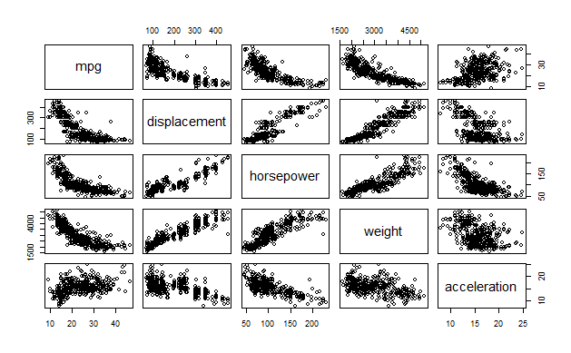

```r
pairs(Auto[, c("mpg", "displacement", "horsepower", "weight", "acceleration")])
```

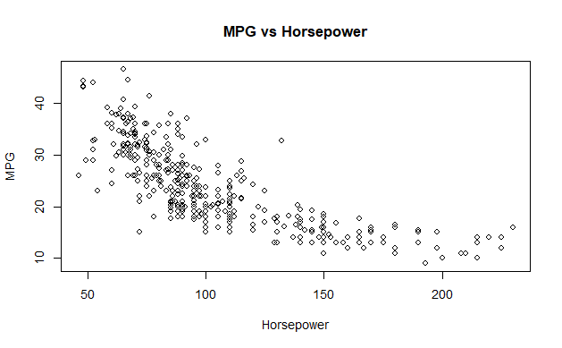

```r
plot(Auto$horsepower, Auto$mpg, main = "MPG vs Horsepower", xlab = "Horsepower", ylab = "MPG")
```

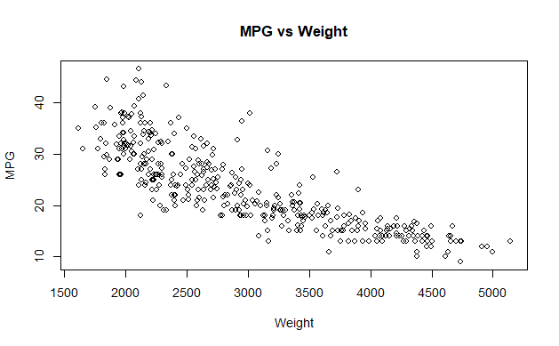

```r
plot(Auto$weight, Auto$mpg, main = "MPG vs Weight", xlab = "Weight", ylab = "MPG")
```

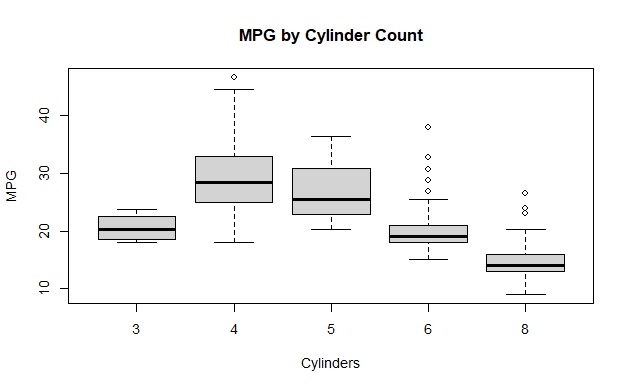

```r
boxplot(Auto$mpg ~ Auto$cylinders, main = "MPG by Cylinder Count", xlab = "Cylinders", ylab = "MPG")
```

```r
cor(Auto[, sapply(Auto, is.numeric)])
```

```
                    mpg  cylinders displacement horsepower     weight acceleration       year     origin
mpg           1.0000000 -0.7776175   -0.8051269 -0.7784268 -0.8322442    0.4233285  0.5805410  0.5652088
cylinders    -0.7776175  1.0000000    0.9508233  0.8429834  0.8975273   -0.5046834 -0.3456474 -0.5689316
displacement -0.8051269  0.9508233    1.0000000  0.8972570  0.9329944   -0.5438005 -0.3698552 -0.6145351
horsepower   -0.7784268  0.8429834    0.8972570  1.0000000  0.8645377   -0.6891955 -0.4163615 -0.4551715
weight       -0.8322442  0.8975273    0.9329944  0.8645377  1.0000000   -0.4168392 -0.3091199 -0.5850054
acceleration  0.4233285 -0.5046834   -0.5438005 -0.6891955 -0.4168392    1.0000000  0.2903161  0.2127458
year          0.5805410 -0.3456474   -0.3698552 -0.4163615 -0.3091199    0.2903161  1.0000000  0.1815277
origin        0.5652088 -0.5689316   -0.6145351 -0.4551715 -0.5850054    0.2127458  0.1815277  1.0000000
```

### Comment: Generally, they all seem to have decent and destinguishable patterns making them rather correlated amongst themselves.

6. Suppose that we wish to predict gas mileage (mpg) on the basis of the other variables. Do your plots suggest that any of the other variables might be useful in predicting mpg? Justify your answer.

# Problem Five:

This question involves the use of simple and multiple linear regression on the Auto data set.

1. Use the `lm()` function to perform a simple linear regression with mpg as the response and horsepower as the predictor. Use the `summary()` function to print the results. Comment on the output.

```r
lmMPGHP <- lm(mpg ~ horsepower, data = Auto)
summary(lmMPGHP)
```

```
Call:
lm(formula = mpg ~ horsepower, data = Auto)

Residuals:
     Min       1Q   Median       3Q      Max
-13.5710  -3.2592  -0.3435   2.7630  16.9240

Coefficients:
             Estimate Std. Error t value Pr(>|t|)
(Intercept) 39.935861   0.717499   55.66   <2e-16 ***
horsepower  -0.157845   0.006446  -24.49   <2e-16 ***
---
Signif. codes:  0 ‘***’ 0.001 ‘**’ 0.01 ‘*’ 0.05 ‘.’ 0.1 ‘ ’ 1

Residual standard error: 4.906 on 390 degrees of freedom
Multiple R-squared:  0.6059,    Adjusted R-squared:  0.6049
F-statistic: 599.7 on 1 and 390 DF,  p-value: < 2.2e-16
```

```r
new_data <- data.frame(horsepower = 98)
predict(lmMPGHP, new_data, interval = "confidence") # 95% confidence interval
```

```
       fit      lwr      upr
1 24.46708 23.97308 24.96108
```

```r
predict(lmMPGHP, new_data, interval = "prediction") # 95% prediction interval
```

```
       fit     lwr      upr
1 24.46708 14.8094 34.12476
```

For example: i. Is there a relationship between the predictor and the response? ii. How strong is the relationship between the predictor and the response? iii. Is the relationship between the predictor and the response positive or negative? iv. What is the predicted mpg associated with a horsepower of 98? What are the associated 95% confidence and prediction intervals?

### Comment: Yes, heavily so, with essentially 99.9999% certainty. The relationship is negative as seen by the negative value bbut also very strong as seen by the R-squared being >.5. ~24.46 is the predicted MPG with 98 HP. Confidence (23.97, 24.96) Prediction (14.81, 34.12)

2. Plot the response and the predictor. Use the `abline()` function to display the least squares regression line.

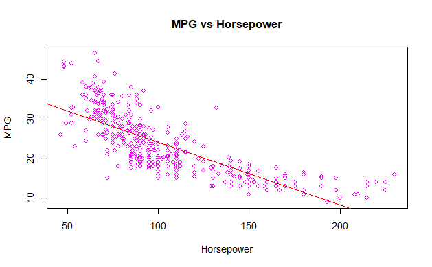

```r
plot(Auto$horsepower, Auto$mpg, main = "MPG vs Horsepower", xlab = "Horsepower", ylab = "MPG", col = "magenta")
abline(lmMPGHP, col = "red")
```

3. Use the `plot()` function to produce diagnostic plots of the least squares regression fit. Comment on any problems you see with the fit.

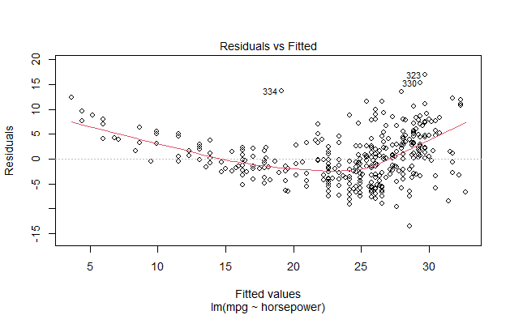

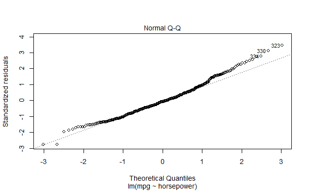

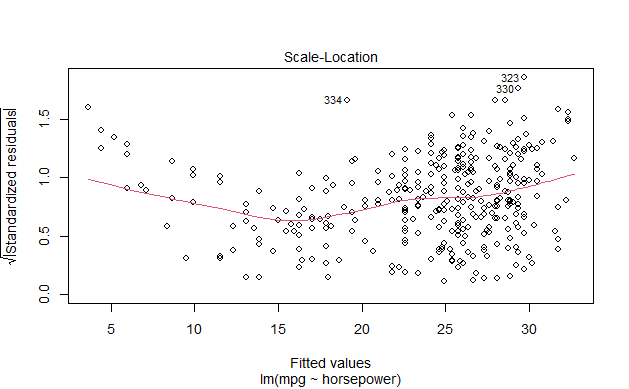

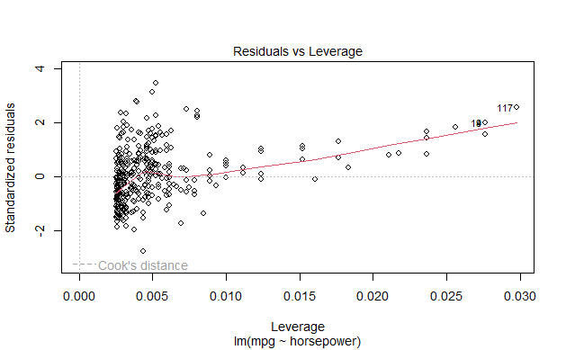

```r
plot(lmMPGHP)
```

### Comment: Heteroscedastic

4. Produce a scatterplot matrix which includes all of the variables in the data set.

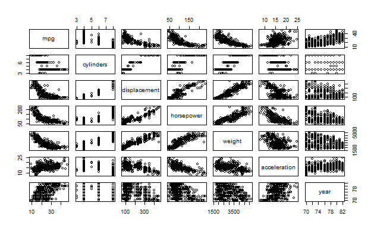

5. Compute the matrix of correlations between the variables using the function `cor()`. You will need to exclude the name variable, which is qualitative.

```r
cor(Auto[, QuantData])
```

```
                    mpg  cylinders displacement horsepower     weight acceleration       year
mpg           1.0000000 -0.7776175   -0.8051269 -0.7784268 -0.8322442    0.4233285  0.5805410
cylinders    -0.7776175  1.0000000    0.9508233  0.8429834  0.8975273   -0.5046834 -0.3456474
displacement -0.8051269  0.9508233    1.0000000  0.8972570  0.9329944   -0.5438005 -0.3698552
horsepower   -0.7784268  0.8429834    0.8972570  1.0000000  0.8645377   -0.6891955 -0.4163615
weight       -0.8322442  0.8975273    0.9329944  0.8645377  1.0000000   -0.4168392 -0.3091199
acceleration  0.4233285 -0.5046834   -0.5438005 -0.6891955 -0.4168392    1.0000000  0.2903161
year          0.5805410 -0.3456474   -0.3698552 -0.4163615 -0.3091199    0.2903161  1.0000000
```

6. Use the `lm()` function to perform a multiple linear regression with mpg as the response and all other variables except name as the predictors. Use the `summary()` function to print the results.

```r
summary(lmMulti)
```

```
Call:
lm(formula = mpg ~ . - name - origin, data = Auto)

Residuals:
    Min      1Q  Median      3Q     Max
-8.6927 -2.3864 -0.0801  2.0291 14.3607

Coefficients:
               Estimate Std. Error t value Pr(>|t|)
(Intercept)  -1.454e+01  4.764e+00  -3.051  0.00244 **
cylinders    -3.299e-01  3.321e-01  -0.993  0.32122
displacement  7.678e-03  7.358e-03   1.044  0.29733
horsepower   -3.914e-04  1.384e-02  -0.028  0.97745
weight       -6.795e-03  6.700e-04 -10.141  < 2e-16 ***
acceleration  8.527e-02  1.020e-01   0.836  0.40383
year          7.534e-01  5.262e-02  14.318  < 2e-16 ***
---
Signif. codes:  0 ‘***’ 0.001 ‘**’ 0.01 ‘*’ 0.05 ‘.’ 0.1 ‘ ’ 1

Residual standard error: 3.435 on 385 degrees of freedom
Multiple R-squared:  0.8093,    Adjusted R-squared:  0.8063
F-statistic: 272.2 on 6 and 385 DF,  p-value: < 2.2e-16
```

Comment on the output. For instance: i. Is there a relationship between the predictors and the response? ii. Which predictors appear to have a statistically significant relationship to the response? iii. What does the coefficient for the year variable suggest?

### Comment: Yes, there is a relationship between the weight and year as well as the intercept. It is rather statistically significant with 99.99% and 99%. The coefficient for the year suggests that there may have been a change in general designs causing there to be a difference from some year onwards.

## Bonus parts for Problem Five

7. Use the * and : symbols to fit linear regression models with interaction effects. Do any interactions appear to be statistically significant?
8. Try a few different transformations of the variables, such as log(X), √X, X2. Comment on your findings.

### Comment:

# Problem Six:

Explore the *mtcars* dataset in R.

Load the dataset into the environment, use the functions you’ve learned so far to look into the data and run a linear model of your choice.

Then share details about your model including: the parameters, the variable chosen, the coefficients for each variable, and the $R^2$.

```r
lmmtcars <- lm(mpg ~ wt + hp + qsec, data = mtcars)
summary(lmmtcars)
```

```
Call:
lm(formula = mpg ~ wt + hp + qsec, data = mtcars)

Residuals:
    Min      1Q  Median      3Q     Max
-3.8591 -1.6418 -0.4636  1.1940  5.6092

Coefficients:
            Estimate Std. Error t value Pr(>|t|)
(Intercept) 27.61053    8.41993   3.279  0.00278 **
wt          -4.35880    0.75270  -5.791 3.22e-06 ***
hp          -0.01782    0.01498  -1.190  0.24418
qsec         0.51083    0.43922   1.163  0.25463
---
Signif. codes:  0 ‘***’ 0.001 ‘**’ 0.01 ‘*’ 0.05 ‘.’ 0.1 ‘ ’ 1

Residual standard error: 2.578 on 28 degrees of freedom
Multiple R-squared:  0.8348,    Adjusted R-squared:  0.8171
F-statistic: 47.15 on 3 and 28 DF,  p-value: 4.506e-11
```